# What Simpsons Episode Should You Watch? An Analysis of Character Dialogue, Interactions, and Ratings

Voshon White

2026-04-17

## Intro

This project uses a collection of data relating to the Fox network’s long-running sitcom “The Simpsons”, created by user named The Devastator on kaggle. The three data sets used contain information regarding character names, dialogue, episode ratings, and episode viewership. Analysis of the relationships between these variables will yield information about the popularity of the show’s characters. This analysis should also highlight trends in the show’s ratings over time, although this insight is not central to the project. Using our findings from exploring the data sets, it will be possible to make specific and relevant episode recommendations to viewers based on what they enjoy most within the show. It is important to note that the data only includes information on the first 600 episodes of the series, which will limit generalization to later seasons.

## Question

**How do character dialogue patterns and interactions between characters influence episode ratings in *The Simpsons* and can these patterns be used to recommend episodes based on personal preference?**

## The Datasets

```r
episodes <- read_csv("simpsons_episodes.csv", show_col_types =FALSE)
scripts <- read_csv("simpsons_script_lines.csv", show_col_types =FALSE)
characters <- read_csv("simpsons_characters.csv", show_col_types =FALSE)
```

Each of these datasets contain information useful to the project’s goal. In simpsons_episodes the key variables ratings, titles, and season will prove useful. In simpsons_script_lines the variables concerning dialogue, episode_id, and character_id will serve as the main variables to be analyzed. Character id and episode id are established in simpsons_characters and simpsons_episodes respectively.

## Data Preparation

To prepare the data for analysis, the individual datasets were combined and cleaned to create a unified dataset. First, the `simpsons_script_lines` dataset was joined with the `simpsons_characters` dataset using `character_id` in order to associate each line of dialogue with a character name. This dataset was then joined with `simpsons_episodes` using `episode_id` to incorporate episode-level information such as ratings and titles.

Observations with missing or undefined character names were removed to ensure accuracy in counting dialogue. The resulting dataset contains dialogue lines linked to both character identities and episode information.

Additional variables had to be created to support analysis, such as counts of dialogue lines per character within each episode, as well as total lines per episode. This allowed for identification of the primary speaker in each episode and enable comparison across episodes.

```r
# Joining the data
data <- scripts %>%
  left_join(characters, by = c("character_id" = "id")) %>%
  left_join(episodes, by = c("episode_id" = "id"))

# Clear missing
data <- data %>%
  filter(!is.na(name))
```

```r
# Count lines by character and then by character per episode
lines_per_char <- data %>%
  group_by(episode_id, name) %>%
  summarise(lines = n(), groups = "drop")

episode_totals <- lines_per_char %>%
  group_by(episode_id) %>%
  summarise(total_lines = sum(lines))
```

## Capturing Patterns in Dialogue and Interaction

To support analysis on the dialogue and interaction between characters in the show new variables were created from the cleaned dataset. These features contain information highlighting patterns about dialogue and interactions at both the character and episode level.

### Character Dialogue

The number of lines of dialogue spoken by each character was counted to find the most prominent characters in the dataset. Doing so allowed for insightful comparison of overall character presence across the entire series.

```r
# Lines per character overall
char_totals <- data %>%
  count(name, sort = TRUE)
```

### Main Character (This Week)

For each episode the character with the most lines of dialogue was identified as the focus of that week. The character with the second most lines of dialgoue was also captured to account to for the possibility that the numbers may skew towards Homer Simpson no matter what.

```r
main_char <- lines_per_char %>%
  group_by(episode_id) %>%
  slice_max(lines, n =1, with_ties = FALSE)

#Secondary Character
second_char <- lines_per_char %>%
  group_by(episode_id) %>%
  slice_max(lines, n = 2, with_ties = FALSE) %>%
  slice_min(lines, n =1)
```

### Interactions

Character Interactions were estimated by examining consecutive lines of dialogue within each episode. Whenever one character talks immediately proceeding another, it is treated as an interaction between the two. In this way communication patterns can be approximated.

```r
# Order
data <- data %>%
  arrange(episode_id, id)

# Subsequent Speaker
data <- data %>%
  mutate(next_speaker = lead(name))

# Count
interactions <- data %>%
  filter(name != next_speaker, !is.na(next_speaker)) %>%
  count(episode_id, name, next_speaker)
```

#Per Episode Variables

Per episode variables were created to support analysis of how dialogue patterns relate to ratings. These variables relate to total lines of dialogue, the number of unique characters and the approximation of the main character.

```r
episode_summary <- lines_per_char %>%
  group_by(episode_id) %>%
  summarise(
    total_lines = sum(lines),
    num_characters = n()
  ) %>%
  left_join(main_char, by = "episode_id") %>%
  left_join(episodes, by = c("episode_id" = "id"))
```

## Exploratory Data Analysis

This is the exploration of the patters in character dialogue and per episode variables to better understand their relationships to episode rating.

### Characters With The Most Lines

To understand which characters appear most in the series, the total number of lines spoken by each character wast totaled. This summation provided insight into overall character prominence.

[figure not shown]

```r
top_chars <- char_totals %>%
  slice_max(n, n =10)

ggplot(top_chars, aes(x = reorder(name, n), y = n)) +
  geom_col() +
  coord_flip() +
  labs(title = "Top 10 Characters by Dialogue",
       x = "Character",
       y = "Number of Lines")
```

Predictably the results show that the four speaking members of the Simpsons nuclear household have the most lines across the series. This suggests that these central characters, especially Homer, will dominate most if not all of the episodes.

### Dialogue Distribution by Episode

The total number of lines of dialogue per episode was counted to better understand dialogue distribution and the variation between episodes.

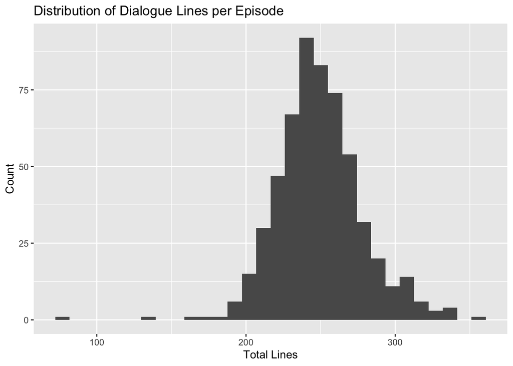

```r
ggplot(episode_summary, aes(x = total_lines)) +
  geom_histogram(bins = 30) +
  labs(title = "Distribution of Dialogue Lines per Episode",
  x = "Total Lines",
  y = "Count"
  )
```

### Ratings by Character Focus

The relationship between an episodes main character it’s ratings were examined to find out whether or not the primary speaker of an episode influences episode ratings. To this end and to support deeper analysis of epsiode focus and ratings the relationship between an episodes second most talkative character and it’s rating was also examined to account for the outsized presence Homer Simpson has in the data.

[figure not shown]

```r
# Main Character Plot
ggplot(episode_summary, aes(x = reorder(name, imdb_rating, median), y = imdb_rating)) +
  geom_boxplot() +
  coord_flip() +
  labs(title = "Episode Ratings by Main Character",
       x = "Main Character",
       y = "IMDb Rating")
```

[figure not shown]

```r
# Second Character Data
second_char_full <- second_char %>%
  left_join(episodes, by = c("episode_id" = "id")) %>%
  ungroup()
# Included Because the Original Plot Was Illegible
top_second <- second_char_full %>%
  count(name, sort = TRUE) %>%
  slice_head(n = 20) %>%
  dplyr::pull(name)

filtered_data <- second_char_full %>%
  dplyr::filter(name %in% top_second)

# Secondary Character Plot
ggplot(filtered_data, aes(x = reorder(name, imdb_rating, median), y = imdb_rating)) +
  geom_boxplot() +
  coord_flip() +
  labs(title = "Episode Ratings by Secondary Character",
       x = "Secondary Character",
       y = "IMDb Rating"
) +
theme(
  axis.tect.y = element_text(size = 7),
  plot.title = element_text(hjust = 0.5)
)
```

The results of both examinations suggest that not only may main character play a role in influencing epsiode ratings but the secondary focus of an episode and the interplay between the two characters may influence it as well.

### Interactions and Their Influence

The relationship between character interactions and episode ratings was examined by exploring how the number of character interactions (as described above) relates to ratings.

[figure not shown]

```r
interaction_counts <- interactions %>%
  group_by(episode_id) %>%
  summarise(total_interactions = sum(n))

episode_summary <- episode_summary %>%
  left_join(interaction_counts, by = "episode_id")

ggplot(episode_summary, aes(x = total_interactions, y = imdb_rating)) +
  geom_point() +
  geom_smooth(method = "lm", se = FALSE, color = "red") +
  labs(title = "Interactions vs Episode Ratings",
       x = "number of Interactions",
       y = "IMDb Rating")
```

It seems that the relationship between character interactions and ratings is weak, with most of the results clustered around 7-8 regardless of character interactions. Thus, there is not a clear trend suggesting that more character interactions leads to higher ratings or that fewer do.

## Analysis

This section combines the results of the exploratory analysis to evaluate how character dialogue patterns and interactions influence episode ratings.

### Main Character Influence

The analysis of episode ratings by main character suggests that character focus does play a role in episode performance. Certain characters are associated with higher median ratings, suggesting that episodes centered around these characters may be more favorably received by viewers.

However, the variation in ratings within each character group suggests that character focus alone is not the end all be all of episode quality. While some characters appear in higher-rated episodes more frequently, there is still considerable overlap across characters.

### Secondary Character Influence

Examining the second-most prominent character in each episode provides additional insight into the role of supporting characters. The results indicate that secondary characters may also influence episode ratings, particularly in episodes where strong character pairings are present.

This suggests that interactions between key characters, rather than the presence of a single dominant character, may contribute to higher-quality episodes.

### Character Interactions and Ratings

The relationship between the number of character interactions and episode ratings appears to be weak. While episodes with a higher number of interactions are present across a range of ratings, there is no clear linear trend indicating that more interactions consistently lead to higher ratings.

A fitted regression line shows only a slight positive relationship, suggesting that interaction count alone is not a strong predictor of episode quality. This indicates that while interactions may contribute to episode engagement, their impact is likely dependent on which characters are interacting rather than the total number of interactions.

### Key Insight

Taken together, these results suggest that character identity and character combinations are more important than the sheer volume of dialogue or interactions. Episodes that feature popular or well-developed character dynamics may achieve higher ratings, even if they do not have the highest number of interactions.

## Conclusion of Analysis

The results show no strong relationship between character dialogue dominance and episode ratings. Although characters like Homer Simpson frequently appear as the primary speaker, their presence does not consistently correspond to higher-rated episodes. Ratings vary widely across all characters, indicating that no single character reliably predicts episode quality. Incorporating the second most talkative character to account for dominant figures such as Homer did not meaningfully change this pattern, as variability in ratings remained high across all character combinations.

While these findings suggest that character focus alone is not a strong predictor of episode success, they do not diminish the value of character-based exploration. Instead, they highlight that viewers’ preferences—such as wanting to watch episodes centered around specific characters—can be meaningfully combined with episode ratings to guide viewing choices.

To address this, a recommendation tool was developed that allows users to input one or more characters they are interested in and returns a list of the highest-rated episodes featuring those characters. Rather than predicting ratings based on character presence, the tool leverages existing ratings to filter and prioritize episodes that align with user preferences. In this way, the analysis supports a more practical approach to episode selection: not by identifying which character guarantees a good episode, but by helping viewers find the best episodes for the characters they already enjoy.

## Recommendations

```r
char_episode <- lines_per_char %>%
  group_by(episode_id, name) %>%
  summarise(lines = sum(lines), .groups = "drop")

char_episode_ratings <- char_episode %>%
  left_join(episodes, by = c("episode_id" = "id"))

recommend_episodes <- function(characters, data, top_n = 10) {

  data %>%
    filter(name %in% characters) %>%
    group_by(episode_id, title, imdb_rating) %>%
    summarise(total_lines = sum(lines), .groups = "drop") %>%
    arrange(desc(imdb_rating)) %>%
    slice_head(n = top_n)
}
```

```r
tool_data <- main_char %>%
  select(episode_id, main_char = name, primary_lines = lines) %>%
  left_join(
    second_char %>%
      select(episode_id, secondary_character = name, secondary_lines = lines),
    by = "episode_id"
  ) %>%
  left_join(
    episodes %>%
      select(id, title, imdb_rating),
    by = c("episode_id" = "id")
  )

tool_data <- tool_data %>%
  ungroup()

primary_choices <- tool_data %>%
  pull(main_char) %>%
  as.character() %>%
  trimws()

primary_choices <- sort(unique(primary_choices[!is.na(primary_choices) & primary_choices != ""]))

secondary_choices <- tool_data %>%
  pull(secondary_character) %>%
  as.character() %>%
  trimws()

secondary_choices <- sort(unique(secondary_choices[!is.na(secondary_choices) & secondary_choices != ""]))
```

```r
ui <- fluidPage(
  titlePanel("Simpsons Episode Recommendation Tool"),
  sidebarLayout(
    sidebarPanel(
      selectInput(
        "primary",
        "Choose primary character:",
        choices = primary_choices,
        selected = primary_choices[1]
      ),
      selectInput(
        "secondary",
        "Choose secondary character:",
        choices = secondary_choices,
        selected = secondary_choices[1]
      )
    ),
    mainPanel(
      DT::DTOutput("results")
    )
  )
)

server <- function(input, output, session) {
  filtered_data <- reactive({
    tool_data %>%
      ungroup() %>%
      filter(
        main_char == input$primary,
        secondary_character == input$secondary
      ) %>%
      arrange(desc(imdb_rating)) %>%
      slice_head(n = 10) %>%
      select(title, imdb_rating, main_char, secondary_character)
  })

  output$results <- DT::renderDT({
    DT::datatable(filtered_data(), rownames = FALSE)
  })
}

shinyApp(ui = ui, server = server)
```

## Data Citation

The Devastator. (2024). *The Simpsons episodes dataset* [Data set]. Kaggle. https://www.kaggle.com/datasets/thedevastator/the-simpsons-episodes-dataset